# Analyzing Peptide Data with the pmartRqc Package

Kelly Stratton, Lisa Bramer

2016-12-23

The pmartRqc package provides functionality for quality control (QC) processing of mass spectrometry (MS) pan-omics data, in particular proteomic (either at the peptide or the protein level), lipidomic, and metabolomic data. This includes data transformation, specification of groups that are to be compared against each other, filtering of features and/or samples, data normalization, and data summarization (correlation, principal components analysis).

Sample datasets are available in the pmartRdata package for each of the following data types: peptide level data, protein level data, lipidomic data, and metabolomic data. Under development are 3 additional packages that will contain functionality for processing MS omics data. These are pmartRstat for statistical analysis, pmartRpq for protein quantification of peptide level data, and pmartRviz for visualization of the data incorporating the statistical results.

This vignette focuses on the quality control of proteomic data at the peptide level. Other vignettes will be available shortly describing analysis of the other data types.

## Data

Below we load in 3 data.frames from the pmartRdata package:

- `pep_edata`: A $p * (n + 1)$ data.frame of expression data, where $p$ is the number of peptides observed and $n$ is the number of samples (an additional peptide identifier/name column should also be present anywhere in the data.frame). Each row corresponds to data for each peptide.
- `pep_fdata`: A data.frame with $n$ rows. Each row corresponds to a sample with one column giving the unique sample identifiers found in e_data column names and other columns providing qualitative and/or quantitative traits of each sample.
- `pep_emeta`: An optional data.frame with at least $p$ rows. Each row corresponds to a peptide with one column giving peptide names (must be named the same as the column in `e_data`) and other columns giving meta information (e.g. mappings of peptides to proteins).

Here, $p$ is 17407 and $n$ is 12. The `pep_fdata` data.frame contains the sample identifier and the condition designation for each sample, either ‘Infection’ (samples that were infected with some pathogen) or ‘Mock’ (uninfected samples used as a control). The `pep_emeta` data.frame contains the peptide identifier column (‘Mass_Tag_ID’), the protein identification name to which each mass tag ID maps (‘Protein’), a reference identifier (‘Ref_ID’), and the peptide sequence (Peptide_Sequence). Note that the mass tag IDs are unique ($n_{peptide} =$ 17407) while the protein identifiers are not ($n_{protein} =$ 2774) since multiple peptides often map to the same protein.

```r
library(MSomicsQC)
library(MSomicsDATA)

data("pep_edata")
dim(pep_edata)
```

```
## [1] 17407    13
```

```r
pep_edata[1:6,1:5]
```

```
##    Mass_Tag_ID Infection1 Infection2 Infection3 Infection4
## 4         1024         NA         NA         NA         NA
## 6         1047   17953839   20071472   20745779   18206556
## 9         1055  109536335  115459820  106127139   74522014
## 14        1104 1752288782 1796561709 1703186182 2438218572
## 16        1110    2571804    4269824    4852871    2630414
## 23        1214  110239193   82436688  100447189  102006001
```

```r
data("pep_fdata")
dim(pep_fdata)
```

```
## [1] 12  2
```

```r
head(pep_fdata)
```

```
##     SampleID Condition
## 1 Infection1 Infection
## 2 Infection2 Infection
## 3 Infection3 Infection
## 4 Infection4 Infection
## 5 Infection5 Infection
## 6 Infection6 Infection
```

```r
data("pep_emeta")
dim(pep_emeta)
```

```
## [1] 17407     4
```

```r
head(pep_emeta)
```

```
##    Mass_Tag_ID    Protein Ref_ID         Peptide_Sequence
## 6         1024 ACBP_HUMAN    324 K.QATVGDINTERPGMLDFTGK.A
## 15        1047 ALBU_HUMAN    580       T.ECCHGDLLECADDR.A
## 20        1055 RL40_HUMAN   9898     K.TITLEVEPSDTIENVK.A
## 35        1104 ALBU_HUMAN    580      K.KVPQVSTPTLVEVSR.N
## 39        1110  CYC_HUMAN   2918          K.TGPNLHGLFGR.K
## 61        1214  G3P_HUMAN   4480             K.VGVNGFGR.I
```

Next we create pepData object, which contains the 3 components loaded above. During object creation, we specify the names of the identifier columns in the `e_data`, `f_data`, and `e_meta` components of the data (`edata_cname = "Mass_Tag_ID", emeta_cname = "Mass_Tag_ID", fdata_cname = "SampleID"`, respectively), as well as the scale of the data (`data_scale = "abundance"`). We can use the `summary` function to get basic summary information for our pepData object.

```r
mypepData <- as.pepData(e_data = pep_edata, f_data = pep_fdata, e_meta = pep_emeta, edata_cname = "Mass_Tag_ID", emeta_cname = "Mass_Tag_ID", fdata_cname = "SampleID", data_scale = "abundance")
class(mypepData)
```

```
## [1] "pepData"
```

```r
summary(mypepData)
```

```
##
## Summary of 'pepData' Object
## ---------------------------
## Unique SampleIDs (f_data)       12
## Unique Mass_Tag_IDs (e_data) 17407
## Unique Mass_Tag_IDs (e_meta) 17407
## Missing Observations         82833
## Proportion Missing           0.366
```

Alternatively, the pmartRdata package contains the corresponding pepData object, which can be loaded as follows.

```r
data("pep_pepData")
class(pep_pepData)
```

```
## [1] "pepData"
```

```r
rm(pep_pepData)
```

We can use the `plot()` function to display box plots for each sample in the pepData object.

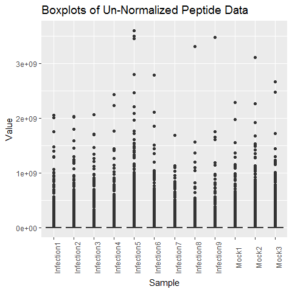

```r
plot(mypepData)
```

### Additional Data

Also included in the pmartR package are protein, metabolite, and lipid data, in analagous formats to the peptide data described above.

```r
edata <- read.csv(system.file("extdata", "metab_edata_sample_names.csv", package="pmartRdata"), header=TRUE)
names(edata)
```

```
##  [1] "Metabolite"   "X1.Mock"      "X2.Mock"      "X3.Mock"
##  [5] "X1.Infection" "X2.Infection" "X3.Infection" "X4.Infection"
##  [9] "X5.Infection" "X6.Infection" "X7.Infection" "X8.Infection"
## [13] "X9.Infection"
```

```r
fdata <- read.csv(system.file("extdata", "metab_fdata_sample_names.csv", package="pmartRdata"), header=TRUE)

# Do the sample names match each other? #
all(names(edata)[-1] == fdata$SampleID)
```

```
## [1] FALSE
```

```r
edata <- read.csv(system.file("extdata", "metab_edata_sample_names.csv", package="pmartRdata"), header=TRUE, check.names=FALSE)
names(edata)
```

```
##  [1] "Metabolite"  "1-Mock"      "2-Mock"      "3-Mock"      "1-Infection"
##  [6] "2-Infection" "3-Infection" "4-Infection" "5-Infection" "6-Infection"
## [11] "7-Infection" "8-Infection" "9-Infection"
```

```r
# Do the sample names match each other? #
all(names(edata)[-1] == fdata$SampleID)
```

```
## [1] TRUE
```

## Workflow

Once the pepData object is created, a typical QC workflow follows the figure below.

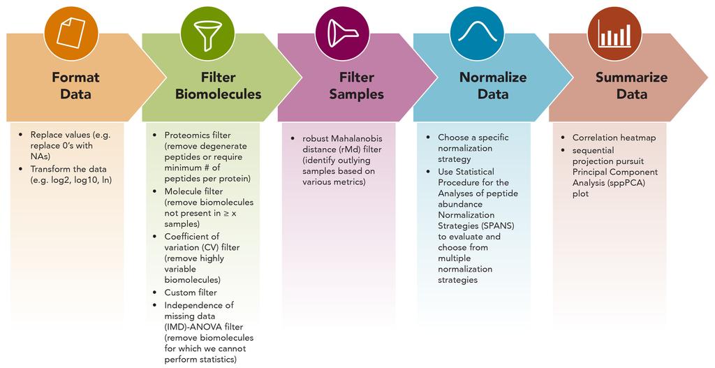

Figure 1. Quality control and processing workflow in pmartRqc package.

We will walk through the steps in this QC workflow using `mypepData`.

### Format Data

```r
mypepData <- edata_replace(mypepData, x = 0, y = NA)
```

```
## [1] "0 instances of 0 have been replaced with NA"
```

In this dataset, there were no 0s so nothing was replaced.

We also recommend log transforming the data prior to analysis. pmartRqc supports log2, log10, and natural logarithm transformations. The `edata_transform()` function provides this capability. We can also use `edata_trasnform()` to transform the data back to the abundance scale if needed. Note that the scale of the data is stored and automatically updated in the `data_info$data_scale` attribute of the pepData object. Below we log10 transform the data, then back transform to the abundance scale, and finally settle on the log2 scale.

```r
mypepData <- edata_transform(mypepData, data_scale = "log10")
attributes(mypepData)$data_info$data_scale
```

```
## [1] "log10"
```

```r
mypepData <- edata_transform(mypepData, data_scale = "abundance")
attributes(mypepData)$data_info$data_scale
```

```
## [1] "abundance"
```

```r
mypepData <- edata_transform(mypepData, data_scale = "log2")
attributes(mypepData)$data_info$data_scale
```

```
## [1] "log2"
```

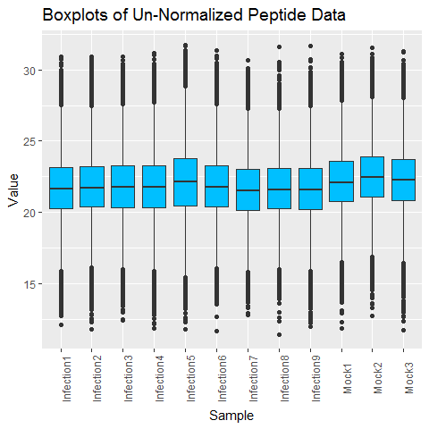

```r
plot(mypepData)
```

Finally, we are preparing this data for statistical analysis where we will compare the samples belonging to one group to the samples belonging to another, and so we must specify the group membership of the samples. We do this using the `group_designation()` function, which modifies our pepData object and returns an updated version of it. Up to two main effects and up to two covariates may be specified, with one main effect being required at minimum. For the example data, we only have one option - specify the main effect to be “Condition” - since we do not have any additional information about the samples. Certain functions we will use below require that groups be designated.

```r
mypepData <- group_designation(mypepData, main_effects = "Condition", covariates = NULL)
```

The `group_designation()` function creates an attribute of the dataset as follows:

```r
attributes(mypepData)$group_DF
```

```
##      SampleID     Group
## 1  Infection1 Infection
## 2  Infection2 Infection
## 3  Infection3 Infection
## 4  Infection4 Infection
## 5  Infection5 Infection
## 6  Infection6 Infection
## 7  Infection7 Infection
## 8  Infection8 Infection
## 9  Infection9 Infection
## 10      Mock1      Mock
## 11      Mock2      Mock
## 12      Mock3      Mock
```

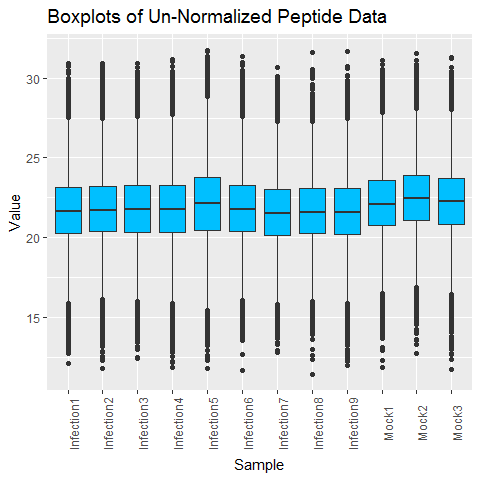

```r
plot(mypepData)
```

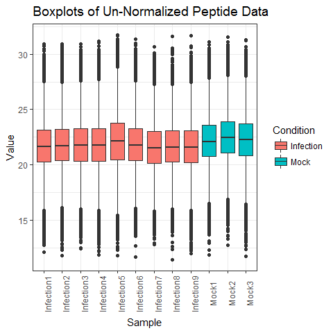

```r
plot(mypepData, color_by = "Condition", bw_theme=TRUE)
```

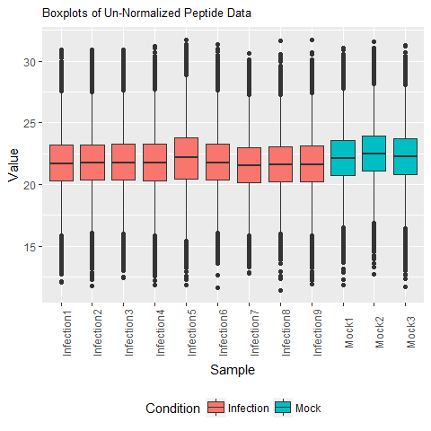

```r
plot(mypepData, color_by = "Condition", title_size=10, legend_position="bottom")
```

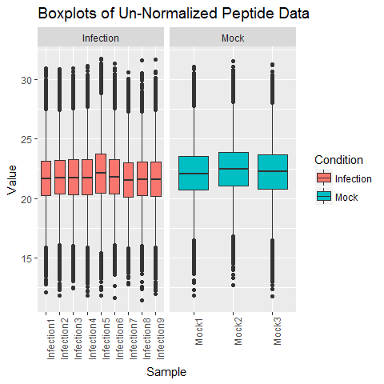

```r
plot(mypepData, facet_by = "Condition", color_by = "Condition")
```

### Filter Peptides

It is often good practice to filter out peptides that do not meet certain criteria, and we offer 5 different filters. Each of the filtering functions calculates metric(s) that can be used to filter out peptides and returns an S3 object. Using the `summary()` function produces a summary of the metric(s) and using the `plot()` function produces a graph. Filters that require a user-specified threshold in order to actually filter out peptides have corresponding `summary` and `plot` methods that take optional argument(s) to specify that threshold. Once one of the 5 peptide level filter functions has been called, the results of that function can be used in conjunction with the `applyFilt()` function to actually filter out peptides based on the metric(s) and user-specified threshold(s) and create a new, filtered pepData object.

#### Proteomics Filter

The proteomics filter is applicable only to peptide level data that contains the `e_meta` component, as it counts the number of peptides that map to each protein and/or the number of proteins to which each individual peptide maps. It returns a list of two character vectors, the first, `peptides_filt`, giving degenerate peptide names. The second, `proteins_filt`, gives the names of proteins which no longer have peptides mapping to them in the dataset. This filter does not require a user-specified threshold.

```r
myfilter <- proteomics_filter(mypepData)
summary(myfilter)
```

```
##
## Summary of Proteomics Filter
##
##              Obs. Per Peptide Obs. Per Protein
## Min.                        1                1
## 1st Qu.                     1                1
## Median                      1                1
## Mean                        1                1
## 3rd Qu.                     1                1
## Max.                        1                1
##
## Filtered                    0                0
## Not Filtered            17407            17407
```

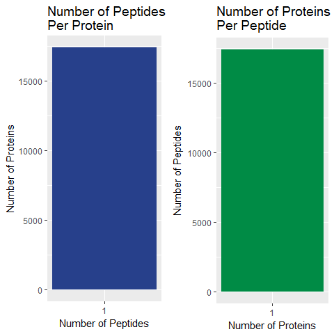

```r
plot(myfilter)
```

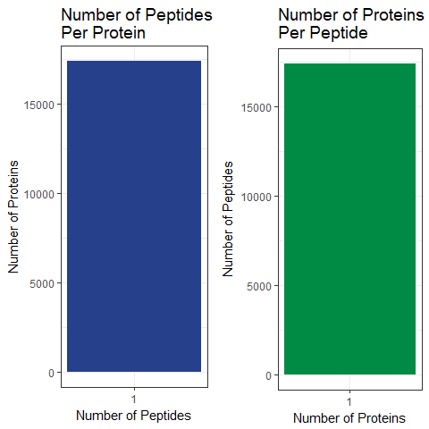

```r
plot(myfilter, bw_theme=TRUE)
```

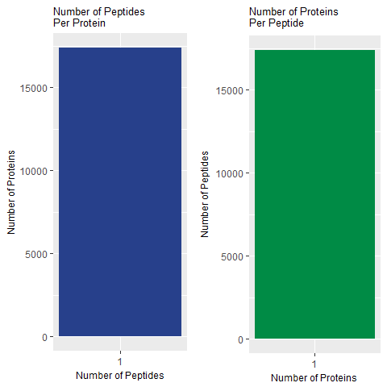

```r
plot(myfilter, title_size=10, x_lab_size=9, y_lab_size=9)
```

With the current dataset, there is a one-to-one mapping between peptides and proteins, so these plots are not very informative. With a many-to-one mapping, we’d see a histogram.

#### Molecule Filter

The molecule filter allows the user to remove from the dataset any biomolecule not seen in at least `min_num` of the samples. The user may specify a threshold of the minimum number of times each biomolecule must be observed across all samples; the default value is 2.

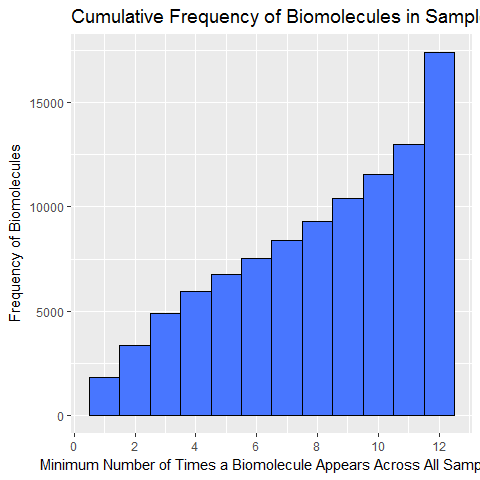

```r
myfilter <- molecule_filter(mypepData)
plot(myfilter)
```

```r
summary(myfilter, min_num = 3)
```

```
##
## Summary of Molecule Filter
## ----------------------------------
## Minimum Number:                  3
## Filtered:                     3342
## Not Filtered:                14065
##
## Molecule Observation Counts:
##
##  num_observations frequency_counts
##                 1             1814
##                 2             3342
##                 3             4911
##                 4             5934
##                 5             6737
##                 6             7530
##                 7             8389
##                 8             9279
##                 9            10383
##                10            11527
##                11            12987
##                12            17407
```

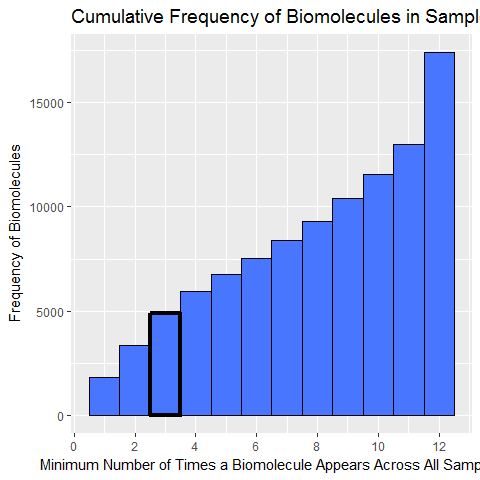

```r
plot(myfilter, min_num = 3)
```

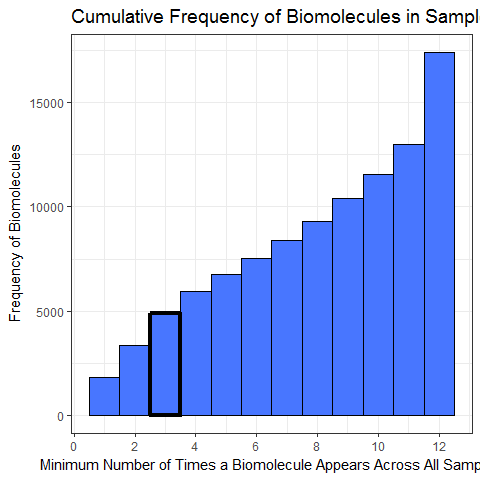

```r
plot(myfilter, min_num = 3, bw_theme = TRUE)
```

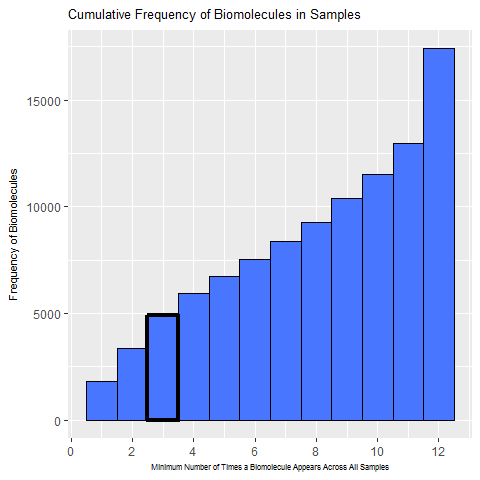

```r
plot(myfilter, min_num = 3, title_size = 10, x_lab_size = 6, y_lab_size = 8)
```

Maybe we don’t want to remove as many peptides as the above would, so we can look at `min_num=2`.

```r
summary(myfilter, min_num = 2)
```

```
##
## Summary of Molecule Filter
## ----------------------------------
## Minimum Number:                  2
## Filtered:                     1814
## Not Filtered:                15593
##
## Molecule Observation Counts:
##
##  num_observations frequency_counts
##                 1             1814
##                 2             3342
##                 3             4911
##                 4             5934
##                 5             6737
##                 6             7530
##                 7             8389
##                 8             9279
##                 9            10383
##                10            11527
##                11            12987
##                12            17407
```

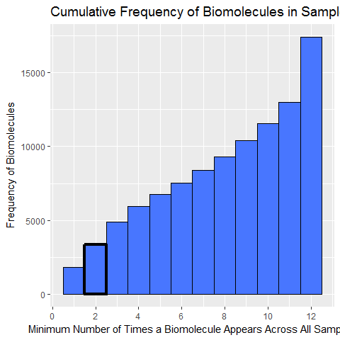

```r
plot(myfilter, min_num = 2)
```

```r
mypepData <- applyFilt(filter_object = myfilter, mypepData, min_num = 2)
summary(mypepData)
```

```
##
## Summary of 'pepData' Object
## ---------------------------
## Unique SampleIDs (f_data)       12
## Unique Mass_Tag_IDs (e_data) 15593
## Unique Mass_Tag_IDs (e_meta) 15593
## Missing Observations         62879
## Proportion Missing            0.31
```

#### Coefficient of Variation Filter

The user can then specify a CV threshold, above which peptides are removed.

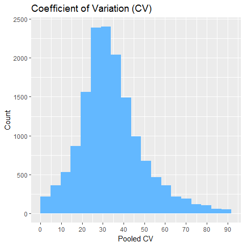

```r
myfilter <- cv_filter(mypepData)
plot(myfilter)
```

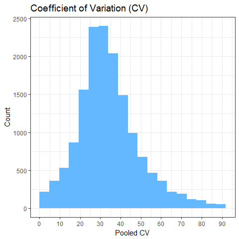

```r
plot(myfilter, bw_theme = TRUE)
```

```r
summary(myfilter, cv_threshold = 150)
```

```
##
## Summary of Coefficient of Variation (CV) Filter
## ----------------------
## CVs:
##
##      Min.   1st Qu.    Median      Mean   3rd Qu.      Max.
##   0.04778  24.86000  32.28000  34.84000  42.00000 168.70000
##
## Total NAs: 359
## Total Non-NAs: 15234
##
## Number Filtered Biomolecules: 2
```

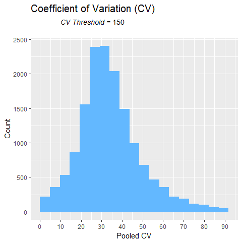

```r
plot(myfilter, cv_threshold = 150, title_size = 15)
```

```r
mypepData <- applyFilt(filter_object = myfilter, mypepData, cv_threshold = 150)
summary(mypepData)
```

```
##
## Summary of 'pepData' Object
## ---------------------------
## Unique SampleIDs (f_data)       12
## Unique Mass_Tag_IDs (e_data) 15591
## Unique Mass_Tag_IDs (e_meta) 15591
## Missing Observations         62871
## Proportion Missing            0.31
```

#### Custom Filter

Sometimes it is known a priori that certain peptides or samples should be filtered out of the dataset prior to statistical analysis. Perhaps there are known contaminant proteins, and so peptides mapping to them should be removed, or perhaps something went wrong during sample preparation for a particular sample.

Here, we remove peptide with Mass Tag ID 1047 and sample `Infection 1` as an example.

```r
myfilter <- custom_filter(mypepData, e_data_remove = 1047, e_meta_remove = 1047, f_data_remove = "Infection 1")
summary(myfilter)
```

```
##
## Summary of Custom Filter
##
##                       Filtered Remaining Total
## SampleIDs (f_data)           1        11    12
## Mass_Tag_IDs (e_data)        1     15590 15591
## Mass_Tag_IDs (e_meta)        1     15590 15591
```

```r
mypepData_temp <- applyFilt(filter_object = myfilter, mypepData)
summary(mypepData_temp)
```

```
##
## Summary of 'pepData' Object
## ---------------------------
## Unique SampleIDs (f_data)       12
## Unique Mass_Tag_IDs (e_data) 15590
## Unique Mass_Tag_IDs (e_meta) 15590
## Missing Observations         62871
## Proportion Missing            0.31
```

```r
rm(mypepData_temp)
```

Note that there is a `summary()` method for objects of type custom_filt, but no `plot()` method.

#### IMD-ANOVA Filter

The IMD-ANOVA filter removes peptides that do not have sufficient data for the available statistical tests in the pmartRstat package. The statistical tests available are ANOVA (quantitative test) and independence of missing data (IMD) using a g-test (qualitative test). When using the `summary()`, `plot()`, and `applyFilt()` functions, you can specify just one filter (ANOVA or IMD) or both, depending on the tests you’d like to perform later. Using this filter speeds up the process of performing the statistical tests.

```r
myfilter <- imdanova_filter(mypepData)
```

Here we consider what the filter would look like for both ANOVA and IMD.

```r
summary(myfilter, min_nonmiss_anova = 2, min_nonmiss_gtest = 3)
```

```
##
## Summary of IMD Filter
##
## Total Observations:  15591
## Filtered:             5739
## Not Filtered:         9852
```

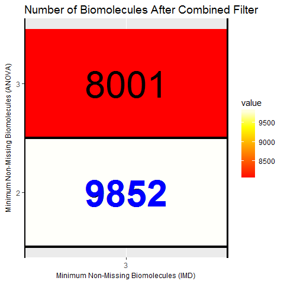

```r
plot(myfilter, min_nonmiss_anova = 2, min_nonmiss_gtest = 3, x_lab_size = 9, y_lab_size = 9)
```

Here we consider what the filter would look like for just ANOVA.

```r
summary(myfilter, min_nonmiss_anova = 2)
```

```
##
## Summary of IMD Filter
##
## Total Observations:  15591
## Filtered:             5511
## Not Filtered:        10080
```

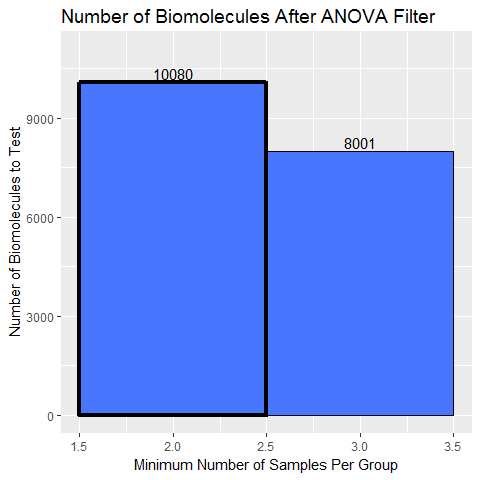

```r
plot(myfilter, min_nonmiss_anova = 2)
```

Here we consider what the filter would look like for just IMD.

```r
summary(myfilter, min_nonmiss_gtest = 3)
```

```
##
## Summary of IMD Filter
##
## Total Observations:  15591
## Filtered:             2280
## Not Filtered:        13311
```

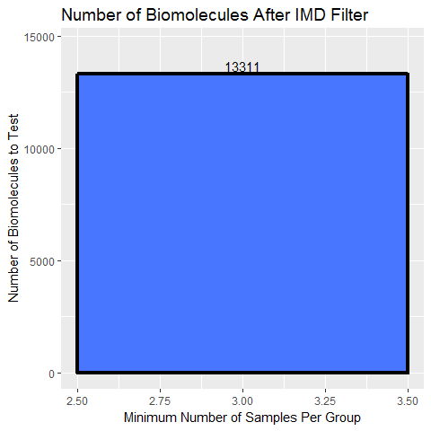

```r
plot(myfilter, min_nonmiss_gtest = 3)
```

Now we apply the filter for both ANOVA and IMD.

```r
mypepData <- applyFilt(filter_object = myfilter, mypepData, min_nonmiss_anova = 2, min_nonmiss_gtest = 3)

summary(mypepData)
```

```
##
## Summary of 'pepData' Object
## ---------------------------
## Unique SampleIDs (f_data)       12
## Unique Mass_Tag_IDs (e_data) 13539
## Unique Mass_Tag_IDs (e_meta) 13539
## Missing Observations         42875
## Proportion Missing           0.244
```

### Filter Samples

To identify any samples that are potential outliers or anomalies (due to sample quality, preparation, or processing circumstances), we use a robust Mahalanobis distance (rMd) score based on 2-5 metrics. The possible metrics are:

- Correlation
- Proportion of data that is missing (“Proportion_Missing”)
- Median absolute deviation (“MAD”)
- Skewness
- Kurtosis

The rMd score can be mapped to a p-value, and a p-value threshold used to identify potentially outlying samples. In general, for proteomics data we recommend using correlation, proportion missing, MAD, and skew.

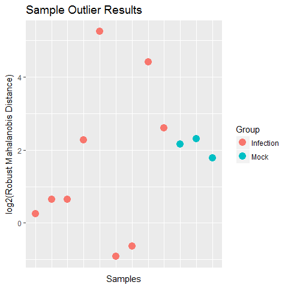

```r
myfilter <- rmd_filter(mypepData, metrics = c("Correlation", "Proportion_Missing", "MAD", "Skewness"))

plot(myfilter)
```

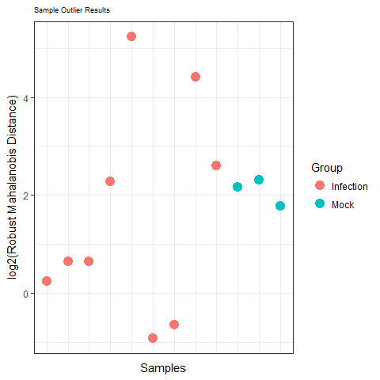

```r
plot(myfilter, title_size=7, bw_theme=TRUE)
```

```r
summary(myfilter, pvalue_threshold = 0.001)
```

```
##
## Summary of RMD Filter
## ----------------------
## P-values:
##
##      Min.   1st Qu.    Median      Mean   3rd Qu.      Max.
## 0.0000001 0.2687000 0.4153000 0.5050000 0.8307000 0.9707000
##
## Metrics Used: MAD, Skewness, Corr, Proportion_Missing
##
## Filtered Samples: Infection5, Infection8
```

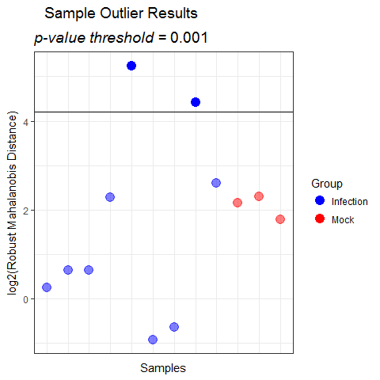

```r
plot(myfilter, pvalue_threshold = 0.001, bw_theme=TRUE)
```

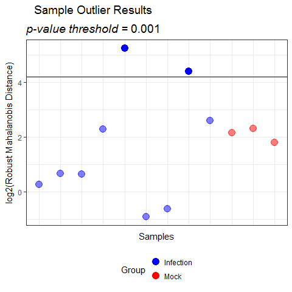

```r
plot(myfilter, pvalue_threshold = 0.001, bw_theme=TRUE, legend_position="bottom")
```

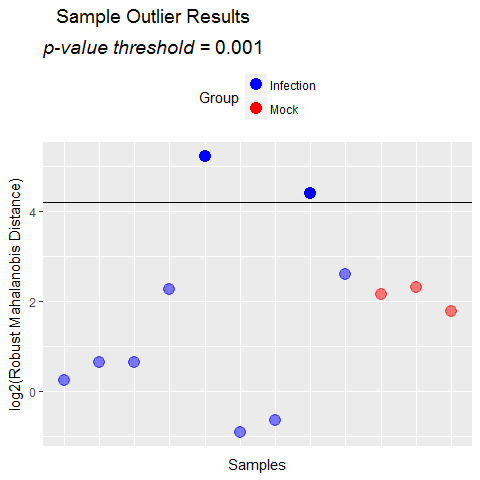

```r
plot(myfilter, pvalue_threshold = 0.001, legend_position="top")
```

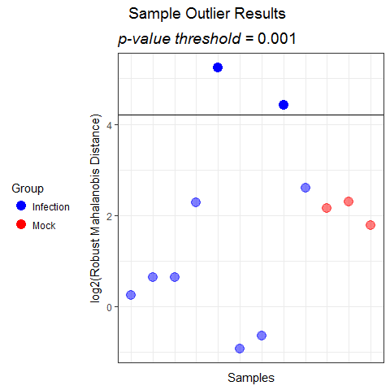

```r
plot(myfilter, pvalue_threshold = 0.001, bw_theme=TRUE, legend_position="left")
```

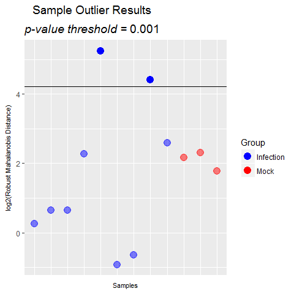

```r
plot(myfilter, pvalue_threshold = 0.001, x_lab_size = 8, y_lab_size = 8)
```

Using the output from the `summary()` function, we can explore the outliers identified to see what metrics are driving their outlier-ness. Box plots for each metric are plotted, with the specified sample marked with an ‘X’.

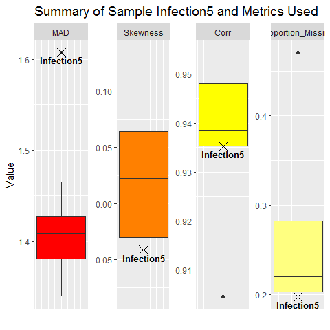

```r
plot(myfilter, sampleID = "Infection5")
```

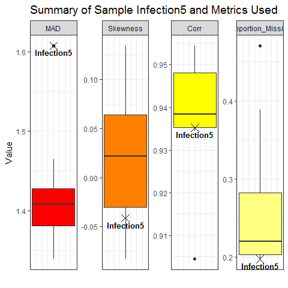

```r
plot(myfilter, sampleID = "Infection5", bw_theme=TRUE)
```

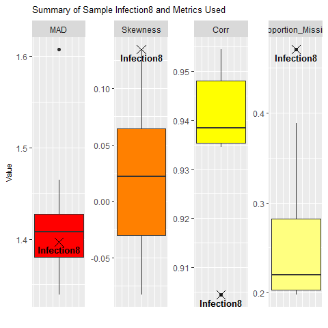

```r
plot(myfilter, sampleID = "Infection8", title_size = 10, y_lab_size=8)
```

We can see that Infection5 has the highest MAD, low skewness, and almost the lowest correlation, but the lowest proportion missing compared to the other samples. Infection 8 has MAD close to the median MAD value, the highest skew, the lowest correlation, and the highest proportion of missing data. We can use this information to determine whether to remove either or both of these samples. Sometimes it is also useful to look at additional data summaries to inform outlier removal, such as a principal components plot or correlation heat map (below).